# 每週一圖作業

#### 環境設定

以下為老師執行時一定會存在的環境設定

```r
library(dplyr); library(stringr); library(ggplot2); library(plotly); library(lubridate); library(readr); library(tidyr); library(showtext)

font_add("QYuan","C:/Users/user/Desktop/cwTeXQYuan-Medium.ttf") # 新增字體
showtext_auto(enable=TRUE) #啟用字體
theme_set(theme_classic())
knitr::opts_chunk$set(out.width='80%', fig.asp=.75, fig.align='center', fig.showtext=T)
```

#### 資料處理

此部份在做：

- 原始Rda資料引入（即引入**dataList**物件）；
- 資料清理成作圖用graphData物件。

請將你最原始的資料連同作業一起上傳到作業上傳網址：  
* 若「原始資料為網頁下載」，且下載指令寫在data cleaning chunk裡的話，可以不用上傳「資料」。  
* 若原始資料有很多個檔案，請先引入成data frame並存在「一個」.Rda檔裡上傳（如`example_data.Rda`檔）。

資料檔引入到進入作圖前的資料處理請寫在下面區塊，分二部份：

- 資料處理
- 作圖用資料物件生成

```r
load(url("https://github.com/tpemartin/course-108-1-inclass-datavisualization/blob/master/%E4%BD%9C%E5%93%81%E5%B1%95%E7%A4%BA/homework2/graphData_homework2_025.Rda?raw=true"))

names(graphData$traffic) %>% # 檢查travelerFromAsia dataframe欄位名稱
tmcn::toUTF8() -> names(graphData$traffic) # 正確轉成utf8 存回原欄位名稱

graphData$traffic %>%
  mutate(
    自強號 = 自強號-自強號[1],
    莒光號 = 莒光號-莒光號[1],
    區間列車 = 區間列車 - 區間列車[1],
    高鐵 = 高鐵 - 高鐵[1]
  ) ->graphData$traffic
graphData$traffic <-graphData$traffic[c("年別","區間列車","高鐵","自強號","莒光號")]
```

#### 繪圖程式

```r
library(grDevices) # 不同顏色模型代碼的呈現及轉換
library(scales) # show_col()螢幕立即顯示顏色
```

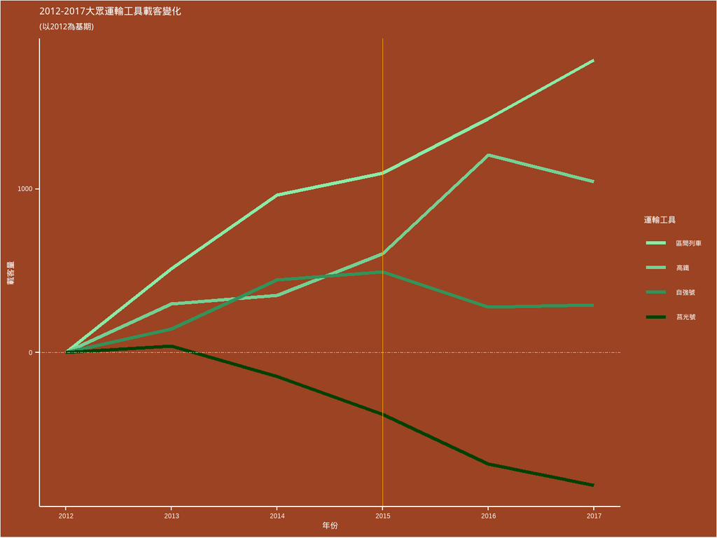

```r
library(colorspace) # 調色盤選擇及ggplot應用工具
library(shinyjs) # 支援套件
#choose_palette(gui="shiny")
colorspace::sequential_hcl(n = 7, h = c(140, 138), c = c(50, NA, 62), l = c(20, 86), power = c(0.7, 1.8), register = "Custom-Palette")

library(reshape2)
graphData$traffic %>%
  melt(id.vars="年別") %>%
    ggplot(aes(x=年別,
               y=value)) +
    geom_line(aes(color=variable),size=1.2
            ) +
  geom_vline(aes(xintercept=2015),size = 0.01,color="orange")+
  geom_hline(aes(yintercept=0),linetype="twodash",size = 0.05,color="gray") +
  scale_color_discrete_sequential(palette = "Custom-Palette",guide=guide_legend("運輸工具"))+
  labs(title = "2012-2017大眾運輸工具載客變化",
       subtitle="(以2012為基期)",
       x = "年份",y = "載客量")+
  theme(plot.background = element_rect(fill = "#9B4322"),
        panel.background = element_rect(fill = "#9B4322"),
        axis.ticks.x = element_line(color = "white"),
        axis.ticks.y = element_line(color = "white"),
        axis.text.x = element_text(color = "white"),
        axis.text.y = element_text(color = "white"),
        axis.title.x = element_text(color = "white"),
        axis.title.y = element_text(color = "white"),
        axis.line = element_line(color = "white"),
        plot.title = element_text(color = "white",face = "bold"),
        plot.subtitle = element_text(color = "white"),
        legend.background = element_rect(fill = "#9B4322"),
        legend.text=element_text(colour="white"),
        legend.title = element_text(color = "white"))
```

#### 設計說明

說明想傳達的訊息（必要）及設計想法（非必要）。寫在*之後* 根據原作者的想傳達的訊息，主要是強調從2012-2017年各大眾交通運輸工具的載客量變化。因此我在此將其改成變化量，並以2012年為基期。 在區間列車方面，載客量年年上升，根據原作者判斷是由於對短程交通的需求升高。 根據原作者的訊息，在2015-2016高鐵苗栗、彰化、雲林站的開通，使高鐵載客量有明顯的上升。而莒光號基本上在2013年之後不斷呈現負成長，自強號也在2015年後載客量有下降趨勢。